# GM12878: parameter choices on real assemblies

This notebook supports the Results section “Parameter choices on real assemblies” (`../manuscript/sections/results_gm12878_parameters.tex`, `sec:parameters`) and Fig. 7 (`fig:parameters`, caption in `figures_main.tex`). It draws Fig. 7 (`figures/fig7_parameters.{pdf,png}`) and computes the numbers the section quotes. Provenance: E40 (release reruns of the start grid, the minimum-length and q-value comparisons, with Trinity added), E06 (homology series), E25 (release runs), E13 and E04 (the earlier development versions of these analyses).

**Which runs.** Everything here is PyTD d3892b5 (E40) at the release defaults, or an option of that code. The homology series was run at a5b24c3, whose code tree is identical to d3892b5 (only documentation differs). No development run is used in this notebook.

```r
ASM <- c("lraa", "stringtie", "trinity")
SHORT <- c(lraa = "LRAA", stringtie = "StringTie", trinity = "Trinity")
asm_factor <- function(x) factor(x, levels = ASM, labels = ASM_LABEL[ASM])

gmr <- read_tab("gm12878", "release_pin", "gm_runs.tsv")
gm_v <- function(a, cfg, col) gmr[[col]][gmr$assembly == a & gmr$config == cfg]
grid <- gmr %>% filter(config == "norefine" | grepl("^a[0-9.]+_w", config)) %>%
  mutate(alpha = suppressWarnings(as.numeric(alpha)), weight = suppressWarnings(as.numeric(weight)),
         # fractions from the counts; the stored 4-digit values can flip the last quoted digit (e.g. 0.7755)
         MANE_sens_exact_given_assembled = MANE_exact / MANE_assembled,
         pred_complete_start_precision = pred_complete_gencode_exact /
           (pred_complete_gencode_exact + pred_complete_compatible_not_exact))
sweep_v7 <- read_tab("gm12878", "final_v7", "08_minaa_sweep_v7.tsv")
by_len <- read_tab("gm12878", "release_pin", "no_overlap_by_length.tsv") %>% mutate(frac = no_gencode_cds_overlap / n)
pm <- read_tab("gm12878", "release_pin", "protein_matches.tsv") %>% separate(label, c("assembly", "setting"), sep = "[.]")
sup_v7 <- read_tab("gm12878", "release_pin", "rule_support.tsv")
hom <- read_tab("gm12878", "gm12878_homology_series_v7h.tsv")
ret_txt <- readLines(data_path("gm12878", "gm12878_homology_primate_retention_v7h.txt"))
te_screen <- read_tab("gm12878", "gm12878_te_screen_v7h.tsv")
```

## Start refinement

Source: `data/gm12878/release_pin/gm_runs.tsv` (E40; PyTD d3892b5 on all three assemblies, fresh runs). The grid is alpha {0.2, 0.4, 0.6, 1} x w {0, 17, 35} bases per bit, plus `--no-refine-starts`. The default cell `a0.4_w17` is byte-identical to the release default run `rel`. It replaces the development grid of E13 (48c870c, LRAA and StringTie, w in nats), which also had the fixed short-ORF test.

```r
g <- function(a, cfg, col) grid[[col]][grid$assembly == a & grid$config == cfg]
stopifnot(all(sapply(ASM, function(a) g(a, "a0.4_w17", "MANE_exact") == gm_v(a, "rel", "MANE_exact"))))
start_tab <- grid %>% filter(config %in% c("norefine", "a0.4_w0", "a0.4_w17", "a1_w17")) %>%
  transmute(assembly, config, `MANE exact given assembled` = MANE_sens_exact_given_assembled,
            `complete, GENCODE exact` = pred_complete_gencode_exact,
            `complete, compatible not exact` = pred_complete_compatible_not_exact,
            `5'-partial` = distinct_predicted_5prime_partial,
            `exact-start share` = pred_complete_start_precision)
kable(start_tab)
```

| assembly | config | MANE exact given assembled | complete, GENCODE exact | complete, compatible not exact | 5’-partial | exact-start share |
| --- | --- | --- | --- | --- | --- | --- |
| lraa | a0.4_w0 | 0.9002224 | 11429 | 2218 | 2942 | 0.8374734 |
| lraa | a0.4_w17 | 0.9291389 | 11828 | 2113 | 2502 | 0.8484327 |
| lraa | a1_w17 | 0.9485224 | 12181 | 2696 | 1067 | 0.8187807 |
| lraa | norefine | 0.5857960 | 7420 | 1609 | 10348 | 0.8217964 |
| stringtie | a0.4_w0 | 0.8844041 | 13001 | 3603 | 3054 | 0.7830041 |
| stringtie | a0.4_w17 | 0.9149008 | 13395 | 3556 | 2646 | 0.7902189 |
| stringtie | a1_w17 | 0.9374369 | 13771 | 3986 | 1254 | 0.7755251 |
| stringtie | norefine | 0.6030945 | 9044 | 3190 | 9483 | 0.7392513 |
| trinity | a0.4_w0 | 0.8727202 | 13100 | 9519 | 6196 | 0.5791591 |
| trinity | a0.4_w17 | 0.8933038 | 13380 | 9413 | 5931 | 0.5870223 |
| trinity | a1_w17 | 0.9106305 | 13707 | 10490 | 3032 | 0.5664752 |
| trinity | norefine | 0.6328817 | 9622 | 8510 | 16006 | 0.5306640 |

```r
M <- "MANE_sens_exact_given_assembled"; X <- "pred_complete_gencode_exact"; PP <- "distinct_predicted_5prime_partial"
SH <- "pred_complete_start_precision"; WS <- "pred_complete_compatible_not_exact"
dpt <- function(a, c1, c2, col) 100 * (g(a, c1, col) - g(a, c2, col))
pv3 <- function(cfg, col) paste(sapply(ASM, function(a) pct(g(a, cfg, col))), collapse = ", ")
nv3 <- function(cfg, col) paste(sapply(ASM, function(a) num(g(a, cfg, col))), collapse = ", ")
```

Values below are LRAA, StringTie, Trinity.

- Exact recovery of fully assembled MANE CDSs: no refinement 58.6%, 60.3%, 63.3%; default 92.9%, 91.5%, 89.3%.
- Exact complete calls: 7,420, 9,044, 9,622 to 11,828, 13,395, 13,380. 5’-partial calls: 10,348, 9,483, 16,006 to 2,502, 2,646, 5,931.
- Exact-start share of GENCODE-compatible complete calls: 82.2%, 73.9%, 53.1% to 84.8%, 79.0%, 58.7%.
- Wrong-start complete calls: 1,609, 3,190, 8,510 to 2,113, 3,556, 9,413.
- Kozak term (w 17 vs 0 at alpha 0.4): 2.9, 3.0, 2.1 points of MANE exact recovery; 1.1, 0.7, 0.8 points of exact-start share.
- alpha 0.4 to 1: MANE exact given assembled 94.9%, 93.7%, 91.1%; wrong-start complete calls 2,696, 3,986, 10,490; exact-start share 81.9%, 77.6%, 56.6%.

E40

## Minimum length and the q-value cutoff

### A 50-codon minimum without a test

Release code with the q-value test switched off (`--max-qvalue 1000000`, because estimated FDRs can exceed 1): `m100_noq` (LongOrfs `-m 100`) and `m50_noq` (`-m 50`). The frame test ($S_1>0$, $C>0$) and the long-ORF rule stay on.

```r
m50_tab <- gmr %>% filter(config %in% c("m100_noq", "m50_noq", "rel")) %>%
  transmute(assembly, config, distinct_cds = distinct_predicted_cds, MANE_exact_given_assembled = MANE_sens_exact_given_assembled,
            no_GENCODE_overlap = pred_all_no_GENCODE_CDS_overlap_frac)
kable(m50_tab)
```

| assembly | config | distinct_cds | MANE_exact_given_assembled | no_GENCODE_overlap |
| --- | --- | --- | --- | --- |
| lraa | m100_noq | 23544 | 0.9279 | 0.0355 |
| lraa | m50_noq | 26542 | 0.9450 | 0.1071 |
| lraa | rel | 22769 | 0.9291 | 0.0150 |
| stringtie | m100_noq | 32672 | 0.9192 | 0.1181 |
| stringtie | m50_noq | 49601 | 0.9317 | 0.3471 |
| stringtie | rel | 30846 | 0.9149 | 0.0547 |
| trinity | m100_noq | 68417 | 0.8966 | 0.1543 |
| trinity | m50_noq | 149993 | 0.9127 | 0.5379 |
| trinity | rel | 59514 | 0.8933 | 0.0425 |

```r
nov <- function(a, cfg) m50_tab$no_GENCODE_overlap[m50_tab$assembly == a & m50_tab$config == cfg]
```

No GENCODE CDS overlap, `-m 100` to `-m 50` without a test: 3.5% to 10.7%; 11.8% to 34.7%; 15.4% to 53.8% (LRAA; StringTie; Trinity). The release default gives 1.5%, 5.5%, 4.2%.

E40

### Matching and non-matching proteins by q setting

Predicted proteins identical to, or sharing an exact 30-residue window with, a GENCODE v50 protein are “matching”; the rest are “non-matching” (`score_protein_matches.py`; `data/gm12878/release_pin/protein_matches.tsv`, E40).

```r
SETTING <- c(precise = "q 0.01 (--precise)", default = "q 0.05 (default)", sensitive = "q 0.2 (--sensitive)")
q_tab <- pm %>% filter(setting %in% c("rel", "precise", "sensitive")) %>%
  mutate(setting = recode(setting, rel = "default")) %>%
  select(assembly, setting, matching = true_positives, nonmatching) %>%
  mutate(cfg = recode(setting, default = "rel"),
         no_GENCODE_overlap = mapply(gm_v, assembly, cfg, "pred_all_no_GENCODE_CDS_overlap_frac"),
         MANE_exact_given_assembled = mapply(gm_v, assembly, cfg, "MANE_sens_exact_given_assembled"),
         catalog_riboseq_orfs = mapply(gm_v, assembly, cfg, "ribo_catalog_stop_match"))
noq <- pm %>% filter(setting == "m50_noq") %>% select(assembly, matching = true_positives, nonmatching)
kable(q_tab %>% mutate(setting = SETTING[setting]) %>% select(-cfg))
```

| assembly | setting | matching | nonmatching | no_GENCODE_overlap | MANE_exact_given_assembled | catalog_riboseq_orfs |
| --- | --- | --- | --- | --- | --- | --- |
| lraa | q 0.05 (default) | 32751 | 277 | 0.0150 | 0.9291 | 101 |
| lraa | q 0.01 (–precise) | 31672 | 189 | 0.0116 | 0.9115 | 79 |
| lraa | q 0.2 (–sensitive) | 33443 | 560 | 0.0233 | 0.9385 | 144 |
| stringtie | q 0.05 (default) | 35294 | 1185 | 0.0547 | 0.9149 | 95 |
| stringtie | q 0.01 (–precise) | 33647 | 698 | 0.0411 | 0.9018 | 81 |
| stringtie | q 0.2 (–sensitive) | 36903 | 2879 | 0.0960 | 0.9266 | 165 |
| trinity | q 0.05 (default) | 78181 | 2616 | 0.0425 | 0.8933 | 186 |
| trinity | q 0.01 (–precise) | 74117 | 1301 | 0.0265 | 0.8779 | 146 |
| trinity | q 0.2 (–sensitive) | 82130 | 7482 | 0.0929 | 0.9035 | 295 |

```r
kable(noq, caption = "No q-value test, 50-codon minimum")
```

No q-value test, 50-codon minimum

| assembly | matching | nonmatching |
| --- | --- | --- |
| lraa | 34382 | 3690 |
| stringtie | 38575 | 18278 |
| trinity | 88821 | 97397 |

```r
q <- function(a, s, col) q_tab[[col]][q_tab$assembly == a & q_tab$setting == s]
nq <- function(a, col) noq[[col]][noq$assembly == a]
fold <- sapply(ASM, function(a) nq(a, "nonmatching") / q(a, "default", "nonmatching"))
loss <- sapply(ASM, function(a) 1 - q(a, "default", "matching") / nq(a, "matching"))
kable(tibble(assembly = ASM, fold_fewer_nonmatching = fold, loss_of_matching = loss), digits = 3)
```

| assembly | fold_fewer_nonmatching | loss_of_matching |
| --- | --- | --- |
| lraa | 13.321 | 0.047 |
| stringtie | 15.424 | 0.085 |
| trinity | 37.231 | 0.120 |

At the default, against no q-value test, non-matching proteins fell 13.3, 15.4, 37.2-fold for a loss of 4.7%, 8.5%, 12.0% of matching ones (LRAA, StringTie, Trinity). Catalogued Ribo-seq ORFs matched by stop codon: 458, 578, 1195 without the test, 101, 95, 186 at the default, 184, 221, 451 at a plain 100-codon minimum and 144, 165, 295 with `--sensitive`.

E40

### Support of the ORFs that the q-value test removed

`data/gm12878/release_pin/rule_support.tsv` (`pipeline/release_pin/14_rule_support_v1.py`, E40). Removed ORFs: predictions of the release code with the q-value test off (`m50_noq`) whose stop codon is not predicted at the release default; ORFs are identified by transcript, strand and stop. Ribo-seq rates are over ORFs with at least ten P-sites; MS rates are over all ORFs (gene models).

```r
kable(sup_v7, caption = "Release code, q-value test off against the default")
```

Release code, q-value test off against the default

| asm | set | n | ribo_n | ribo_sup | ribo_rate | ms_sup | ms_rate |
| --- | --- | --- | --- | --- | --- | --- | --- |
| lraa | baseline_no_q_test | 38072 | 20570 | 13330 | 0.6480 | 22260 | 0.5847 |
| lraa | all | 33028 | 19862 | 13057 | 0.6574 | 21298 | 0.6448 |
| lraa | kept | 32796 | 19730 | 12993 | 0.6585 | 21148 | 0.6448 |
| lraa | removed | 5276 | 840 | 337 | 0.4012 | 1112 | 0.2108 |
| lraa | added | 232 | 105 | 46 | 0.4381 | 122 | 0.5259 |
| stringtie | baseline_no_q_test | 56853 | 20513 | 12419 | 0.6054 | 26790 | 0.4712 |
| stringtie | all | 36479 | 19776 | 12164 | 0.6151 | 25112 | 0.6884 |
| stringtie | kept | 36116 | 19672 | 12110 | 0.6156 | 24943 | 0.6906 |
| stringtie | removed | 20737 | 841 | 309 | 0.3674 | 1847 | 0.0891 |
| stringtie | added | 363 | 96 | 53 | 0.5521 | 157 | 0.4325 |
| trinity | baseline_no_q_test | 186218 | 44741 | 26735 | 0.5976 | 58555 | 0.3144 |
| trinity | all | 80797 | 41725 | 25542 | 0.6122 | 52141 | 0.6453 |
| trinity | kept | 79906 | 41431 | 25420 | 0.6136 | 51718 | 0.6472 |
| trinity | removed | 106312 | 3310 | 1315 | 0.3973 | 6837 | 0.0643 |
| trinity | added | 891 | 302 | 127 | 0.4205 | 433 | 0.4860 |

```r
s7 <- function(a, set, col) sup_v7[[col]][sup_v7$asm == a & sup_v7$set == set]
```

ORFs removed vs all default predictions (LRAA; StringTie; Trinity):

- Ribo-seq frame test passed: 40%, 37%, 40% of removed ORFs with enough footprints (n = 840, 841, 3,310), against 66%, 62%, 61% of all predictions.
- MS peptide: 21%, 9%, 6% against 64%, 69%, 65%.

E40, E01, E02

### Unannotated predictions by length

From the pinned-commit `pred_status` tables (`data/gm12878/release_pin/no_overlap_by_length.tsv`; predicted protein length, the first bin includes the few predictions under 50 aa).

```r
bl <- by_len %>% mutate(pct = round(100 * frac, 1)) %>%
  select(assembly, config, length_bin, n, pct) %>%
  pivot_wider(names_from = length_bin, values_from = c(n, pct))
kable(bl)
```

| assembly | config | n_<100 | n_100-149 | n_150-199 | n_200-299 | n_>=300 | pct_<100 | pct_100-149 | pct_150-199 | pct_200-299 | pct_>=300 |
| --- | --- | --- | --- | --- | --- | --- | --- | --- | --- | --- | --- |
| lraa | rel | 536 | 1627 | 2217 | 4330 | 14059 | 10.6 | 5.0 | 3.2 | 1.8 | 0.4 |
| lraa | m50_noq | 3639 | 2297 | 2243 | 4305 | 14058 | 60.6 | 18.0 | 4.3 | 1.7 | 0.4 |
| stringtie | rel | 2272 | 3082 | 3298 | 5438 | 16756 | 18.8 | 13.7 | 9.6 | 5.9 | 1.2 |
| stringtie | m50_noq | 18654 | 5120 | 3626 | 5453 | 16748 | 76.8 | 35.3 | 15.0 | 6.2 | 1.2 |
| trinity | rel | 4061 | 7648 | 7498 | 11435 | 28872 | 16.0 | 10.6 | 6.2 | 3.4 | 0.7 |
| trinity | m50_noq | 86947 | 14573 | 8207 | 11405 | 28861 | 84.5 | 39.0 | 11.2 | 3.5 | 0.7 |

```r
short_rel <- by_len %>% filter(config == "rel", length_bin %in% c("<100", "100-149"))
long_rel <- by_len %>% filter(config == "rel", length_bin == ">=300")
```

Release defaults: 5%–19% of predictions shorter than 100 aa or of 100–149 aa have no GENCODE CDS overlap, against 0.4%–1.2% of those of at least 300 aa.

### Post-hoc minimum length

`eval_genome_cds.py --min-aa L` on the release default predictions (`data/gm12878/final_v7/08_minaa_sweep_v7.tsv`, `pipeline/derive/08_minaa_sweep_final_v7.sh`; those predictions are byte-identical at the pinned commit, E40). The filter keeps predictions encoding at least L aa (stop excluded); it is applied after prediction, so training and per-transcript selection still see all candidates.

```r
mt <- sweep_v7 %>% select(assembly, min_aa, distinct_predicted_cds, MANE_sens_exact_given_assembled,
                          pred_all_no_GENCODE_CDS_overlap_frac)
kable(mt, digits = 4)
```

| assembly | min_aa | distinct_predicted_cds | MANE_sens_exact_given_assembled | pred_all_no_GENCODE_CDS_overlap_frac |
| --- | --- | --- | --- | --- |
| lraa | 50 | 22734 | 0.9287 | 0.0146 |
| lraa | 60 | 22696 | 0.9279 | 0.0143 |
| lraa | 70 | 22633 | 0.9266 | 0.0139 |
| lraa | 80 | 22554 | 0.9236 | 0.0137 |
| lraa | 90 | 22443 | 0.9201 | 0.0134 |
| lraa | 100 | 22233 | 0.9125 | 0.0128 |
| lraa | 150 | 20606 | 0.8513 | 0.0099 |
| lraa | 200 | 18389 | 0.7688 | 0.0071 |
| lraa | 300 | 14059 | 0.5996 | 0.0038 |
| stringtie | 50 | 30755 | 0.9148 | 0.0538 |
| stringtie | 60 | 30614 | 0.9145 | 0.0527 |
| stringtie | 70 | 30275 | 0.9132 | 0.0506 |
| stringtie | 80 | 29619 | 0.9109 | 0.0487 |
| stringtie | 90 | 29098 | 0.9082 | 0.0466 |
| stringtie | 100 | 28574 | 0.9039 | 0.0441 |
| stringtie | 150 | 25492 | 0.8575 | 0.0329 |
| stringtie | 200 | 22194 | 0.7919 | 0.0235 |
| stringtie | 300 | 16756 | 0.6477 | 0.0119 |
| trinity | 50 | 59353 | 0.8932 | 0.0416 |
| trinity | 60 | 59002 | 0.8930 | 0.0404 |
| trinity | 70 | 58606 | 0.8919 | 0.0396 |
| trinity | 80 | 57786 | 0.8897 | 0.0376 |
| trinity | 90 | 56778 | 0.8867 | 0.0359 |
| trinity | 100 | 55453 | 0.8820 | 0.0338 |
| trinity | 150 | 47805 | 0.8286 | 0.0223 |
| trinity | 200 | 40307 | 0.7555 | 0.0149 |
| trinity | 300 | 28872 | 0.6036 | 0.0072 |

```r
mv <- function(a, L, col) sweep_v7[[col]][sweep_v7$assembly == a & sweep_v7$min_aa == L]
full_mane <- sapply(ASM, gm_v, "rel", "MANE_sens_exact_given_assembled")
```

Removing release predictions below 150 aa cuts the no-overlap share to 1.0% (LRAA), 3.3% (StringTie) and 2.2% (Trinity), while MANE exact given assembled falls from 0.93, 0.91 and 0.89 (unfiltered) to 0.85, 0.86 and 0.83. Between 50 and 100 aa, MANE exact given assembled changes by -0.016, -0.011, -0.011 and the no-overlap share by -0.2, -1.0, -0.8 points (LRAA, StringTie, Trinity).

E40

## Homology evidence and evolutionary distance

Source: `data/gm12878/gm12878_homology_series_v7h.tsv` (E06 release rerun; run at a5b24c3, same code tree as the pinned d3892b5, with the homology-assisted start refinement, release defaults; one fresh LongOrfs per assembly; the ab initio row is byte-identical to the pinned-commit default run). Change = configuration minus ab initio.

```r
CLADES <- c("9606" = "human", "9443" = "primates", "40674" = "mammals", "7742" = "vertebrates",
            "33208" = "animals")
h <- function(a, cfg, col) hom[[col]][hom$assembly == a & hom$config == cfg]
hom_d <- hom %>% group_by(assembly) %>%
  mutate(d_mane_exact_pts = 100 * (MANE_sens_exact_given_assembled - MANE_sens_exact_given_assembled[config == "abinitio"]),
         d_mane_compat_pts = 100 * (MANE_sens_compatible - MANE_sens_compatible[config == "abinitio"]),
         d_distinct_cds = distinct_predicted_cds - distinct_predicted_cds[config == "abinitio"]) %>%
  ungroup()
kable(hom_d %>% select(assembly, config, distinct_predicted_cds, MANE_sens_exact_given_assembled,
                       d_mane_exact_pts, d_mane_compat_pts, d_distinct_cds), digits = 3)
```

| assembly | config | distinct_predicted_cds | MANE_sens_exact_given_assembled | d_mane_exact_pts | d_mane_compat_pts | d_distinct_cds |
| --- | --- | --- | --- | --- | --- | --- |
| lraa | abinitio | 22769 | 0.929 | 0.00 | 0.00 | 0 |
| lraa | blast_9606_nopfam | 24300 | 0.973 | 4.37 | 1.49 | 1531 |
| lraa | blast_9443_nopfam | 24203 | 0.971 | 4.21 | 1.42 | 1434 |
| lraa | blast_40674_nopfam | 23590 | 0.947 | 1.83 | 0.65 | 821 |
| lraa | blast_7742_nopfam | 23253 | 0.938 | 0.91 | 0.30 | 484 |
| lraa | blast_33208_nopfam | 23129 | 0.936 | 0.66 | 0.19 | 360 |
| lraa | pfam | 23959 | 0.948 | 1.89 | 0.75 | 1190 |
| lraa | blast_9606_pfam | 24397 | 0.973 | 4.39 | 1.49 | 1628 |
| lraa | blast_9443_pfam | 24306 | 0.971 | 4.21 | 1.41 | 1537 |
| lraa | blast_40674_pfam | 24099 | 0.955 | 2.58 | 0.95 | 1330 |
| lraa | blast_7742_pfam | 24026 | 0.950 | 2.05 | 0.78 | 1257 |
| lraa | blast_33208_pfam | 24002 | 0.949 | 1.97 | 0.76 | 1233 |
| stringtie | abinitio | 30846 | 0.915 | 0.00 | 0.00 | 0 |
| stringtie | blast_9606_nopfam | 36088 | 0.960 | 4.50 | 3.50 | 5242 |
| stringtie | blast_9443_nopfam | 34660 | 0.960 | 4.46 | 3.44 | 3814 |
| stringtie | blast_40674_nopfam | 32520 | 0.937 | 2.22 | 1.70 | 1674 |
| stringtie | blast_7742_nopfam | 31763 | 0.927 | 1.24 | 0.92 | 917 |
| stringtie | blast_33208_nopfam | 31438 | 0.922 | 0.72 | 0.52 | 592 |
| stringtie | pfam | 33328 | 0.933 | 1.85 | 1.89 | 2482 |
| stringtie | blast_9606_pfam | 36335 | 0.961 | 4.64 | 3.66 | 5489 |
| stringtie | blast_9443_pfam | 34928 | 0.960 | 4.55 | 3.58 | 4082 |
| stringtie | blast_40674_pfam | 33770 | 0.943 | 2.79 | 2.44 | 2924 |
| stringtie | blast_7742_pfam | 33495 | 0.937 | 2.21 | 2.14 | 2649 |
| stringtie | blast_33208_pfam | 33414 | 0.934 | 1.91 | 1.99 | 2568 |
| trinity | abinitio | 59514 | 0.893 | 0.00 | 0.00 | 0 |
| trinity | blast_9606_nopfam | 75523 | 0.936 | 4.30 | 3.26 | 16009 |
| trinity | blast_9443_nopfam | 70516 | 0.936 | 4.27 | 3.20 | 11002 |
| trinity | blast_40674_nopfam | 64164 | 0.914 | 2.10 | 1.59 | 4650 |
| trinity | blast_7742_nopfam | 62087 | 0.904 | 1.04 | 0.79 | 2573 |
| trinity | blast_33208_nopfam | 61283 | 0.900 | 0.68 | 0.50 | 1769 |
| trinity | pfam | 65802 | 0.916 | 2.27 | 2.28 | 6288 |
| trinity | blast_9606_pfam | 76278 | 0.937 | 4.34 | 3.54 | 16764 |
| trinity | blast_9443_pfam | 71341 | 0.936 | 4.30 | 3.49 | 11827 |
| trinity | blast_40674_pfam | 67431 | 0.921 | 2.80 | 2.71 | 7917 |
| trinity | blast_7742_pfam | 66377 | 0.916 | 2.28 | 2.40 | 6863 |
| trinity | blast_33208_pfam | 66146 | 0.915 | 2.22 | 2.35 | 6632 |

```r
dh <- function(a, cfg, col) hom_d[[col]][hom_d$assembly == a & hom_d$config == cfg]
```

- Swiss-Prot minus human, MANE exact given assembled: +4.4 (LRAA), +4.5 (StringTie), +4.3 (Trinity) points; MANE compatible +1.5, +3.5, +3.3.
- Minus all animals: +0.7, +0.7, +0.7.
- Pfam alone: 94.8%, 93.3%, 91.6%; Swiss-Prot minus human: 97.3%, 96.0%, 93.6%.

E06

## Homology to transposable elements retains short unannotated ORFs

Source: `data/gm12878/gm12878_homology_primate_retention_v7h.txt` (E06 release rerun; `homology_series_retention.py`, Swiss-Prot minus human vs minus primates, BLAST only). Parsed below.

```r
prot_n <- function(line, prot) {
  m <- regmatches(line, regexec(sprintf("\\('%s', (\\d+)\\)", prot), line))[[1]]
  if (length(m) == 2) as.integer(m[2]) else 0L
}
parse_ret <- function(asm, txt = ret_txt) {
  i <- which(txt == paste("==", asm))
  blk <- txt[(i + 1):(i + 4)]
  n_only <- as.integer(sub("in A only: (\\d+) .*", "\\1", blk[1]))
  novel <- as.integer(sub(".*'novel': (\\d+).*", "\\1", blk[1]))
  short <- as.integer(sub(".*short\\(<100aa\\): (\\d+).*", "\\1", blk[1]))
  tibble(assembly = asm, only_minus_human = n_only, unannotated = novel, short_lt100 = short,
         best_hit_UTY_PANTR = prot_n(blk[3], "UTY_PANTR"), best_hit_LIN1_NYCCO = prot_n(blk[3], "LIN1_NYCCO"),
         best_hit_LORF2_MOUSE = prot_n(blk[3], "LORF2_MOUSE"))
}
ret <- bind_rows(parse_ret("trinity"), parse_ret("stringtie"), parse_ret("lraa"))
kable(ret, caption = "Release (a5b24c3)")
```

Release (a5b24c3)

| assembly | only_minus_human | unannotated | short_lt100 | best_hit_UTY_PANTR | best_hit_LIN1_NYCCO | best_hit_LORF2_MOUSE |
| --- | --- | --- | --- | --- | --- | --- |
| trinity | 5127 | 4791 | 4506 | 4555 | 201 | 1 |
| stringtie | 1532 | 1426 | 1229 | 1353 | 41 | 2 |
| lraa | 150 | 108 | 104 | 95 | 4 | 0 |

```r
r <- function(a, col) ret[[col]][ret$assembly == a]
```

Trinity: 5,127 distinct CDSs with Swiss-Prot minus human but not minus primates; 4,791 with no annotated CDS overlap; 88% encode fewer than 100 aa (4,506, counted over all 5,127); 4,555 have chimpanzee UTY as best hit and 201 a primate LINE-1 protein (LIN1_NYCCO). MANE exact (all MANE): 0.3738 (minus human) and 0.3737 (minus primates). StringTie: 1,353 of 1,426. These numbers also appear in the Fig. 7d annotation.

E06

Transposable-element screen (`pipeline/derive/08_te_screen_check_v7h.sh`, the recipe of PyTD `docs/homology_te_screen.md`, d3892b5): ORFs predicted with Swiss-Prot minus human (BLAST only) but not ab initio, flagged by best-hit name, by at least half of the CDS in RepeatMasker TEs, or either.

```r
kable(te_screen)
```

| assembly | homology_run | predicted | abinitio | homology_only | flag_by_name | flag_by_overlap | flag_either | homology_only_genome_mapped | best_hit_UTY_PANTR | UTY_PANTR_genome_mapped | UTY_PANTR_flag_by_overlap |
| --- | --- | --- | --- | --- | --- | --- | --- | --- | --- | --- | --- |
| lraa | blast_9606_nopfam | 35361 | 33028 | 2545 | 60 | 184 | 185 | 2545 | 116 | 116 | 107 |
| stringtie | blast_9606_nopfam | 42315 | 36479 | 6229 | 467 | 2066 | 2068 | 6229 | 1534 | 1534 | 1466 |
| trinity | blast_9606_nopfam | 101681 | 80797 | 21646 | 2153 | 7106 | 7396 | 18912 | 6743 | 5098 | 4970 |

## Figure 7

Port of `figures/fig7_parameters/make_fig7.py`. All panels are from the pinned release code (E40):

- 1. the alpha x w grid on all three assemblies; the default cell is the release default.
- (b) lines are the post-hoc filter on the release predictions; markers are the q settings at the 50-codon minimum: q 0.01, q 0.05 (default) and q 0.2 (drawn at 45, 50 and 55 aa so they do not overlap).
- (c, d) the homology series (E06).

```r
# (a) start refinement
pa_dat <- grid %>% filter(config != "norefine", weight %in% c(0, 17)) %>%
  mutate(w = ifelse(weight == 17, "w = 17/bit", "w = 0"), assembly = factor(assembly, levels = ASM))
pa_lab <- pa_dat %>% filter(weight == 17, alpha %in% c(0.2, 1.0)) %>%
  mutate(label = paste0("α = ", alpha))
pa_def <- pa_dat %>% filter(weight == 17, alpha == 0.4)
pa <- ggplot(pa_dat, aes(MANE_sens_exact_given_assembled, pred_complete_start_precision,
                         colour = assembly, group = interaction(assembly, w))) +
  geom_path(aes(linetype = w), linewidth = 0.4) +
  geom_point(aes(shape = w), size = 1.1, fill = "white", stroke = 0.5) +
  geom_point(data = pa_def, aes(group = NULL), shape = 21, size = 3, colour = "black", stroke = 0.35) +
  geom_text(data = pa_lab, aes(label = label, group = NULL, hjust = ifelse(alpha < 0.5, 1.15, -0.1),
                               vjust = ifelse(alpha < 0.5, 0.5, 1.3)),
            size = 1.95, show.legend = FALSE) +
  scale_colour_manual(values = ASM_COLOR, labels = ASM_LABEL, guide = "none") +
  scale_linetype_manual(values = c("w = 17/bit" = "solid", "w = 0" = "22"), name = NULL) +
  scale_shape_manual(values = c("w = 17/bit" = 16, "w = 0" = 21), name = NULL) +
  coord_cartesian(xlim = c(0.83, 0.975)) +
  scale_y_continuous(breaks = seq(0.5, 0.9, 0.1)) +
  labs(x = "MANE exact given assembled", y = "exact-start share of\ncompatible complete calls",
       title = "Start refinement (α)", caption = "large circle: release default") +
  theme(plot.caption = element_text(size = 5.5, hjust = 0)) +
  theme(legend.position = "inside", legend.position.inside = c(0.02, 0.5), legend.justification = c(0, 0.5),
        legend.key.width = unit(5, "mm"))

# (b) minimum length
QSET <- c(precise = "q 0.01", default = "q 0.05 (default)", sensitive = "q 0.2")
QSHAPE <- c("q 0.01" = 25, "q 0.05 (default)" = 23, "q 0.2" = 24)
pb_lines <- sweep_v7 %>% mutate(assembly = factor(assembly, levels = ASM))
# markers drawn at 45 / 50 / 55 aa so they do not overlap; all three runs use the 50-codon minimum
pb_pts <- q_tab %>% mutate(qs = factor(QSET[setting], levels = QSET),
                           min_aa = c(precise = 45, default = 50, sensitive = 55)[setting],
                           assembly = factor(assembly, levels = ASM))
panel_b <- function(col_line, col_pt, ylab, title, legend = FALSE) {
  ggplot(pb_lines, aes(min_aa, .data[[col_line]], colour = assembly)) +
    geom_vline(xintercept = 50, colour = "grey50", linewidth = 0.3, linetype = "dotted") +
    geom_line(linewidth = 0.4) + geom_point(size = 0.8) +
    geom_point(data = pb_pts, aes(y = .data[[col_pt]], shape = qs), fill = "white", size = 1.6,
               stroke = 0.5) +
    scale_colour_manual(values = ASM_COLOR, guide = "none") +
    scale_shape_manual(values = QSHAPE, name = NULL, drop = FALSE) +
    scale_x_continuous(breaks = c(50, 100, 150, 200, 300)) +
    labs(x = "minimum protein length (aa)", y = ylab, title = title) +
    theme(legend.position = if (legend) "inside" else "none", legend.position.inside = c(0.98, 0.98), legend.justification = c(1, 1))
}
pb1 <- panel_b("MANE_sens_exact_given_assembled", "MANE_exact_given_assembled",
               "MANE exact given\nassembled", "Minimum length: accuracy")
pb2 <- panel_b("pred_all_no_GENCODE_CDS_overlap_frac", "no_GENCODE_overlap",
               "no GENCODE CDS\noverlap (fraction)", "Minimum length: unannotated", legend = TRUE)

# (c, d) homology
XLEV <- c(paste0("−", CLADES), "Pfam\nonly")
PFAM_X <- 5.6
hom_pl <- hom_d %>% filter(config != "abinitio") %>%
  mutate(taxid = sub("blast_(\\d+)_.*", "\\1", config),
         db = case_when(config == "pfam" ~ "Pfam only",
                        grepl("_nopfam$", config) ~ "Swiss-Prot",
                        TRUE ~ "Swiss-Prot + Pfam"),
         x = ifelse(config == "pfam", "Pfam\nonly", paste0("−", CLADES[taxid])),
         xn = ifelse(config == "pfam", PFAM_X, match(x, XLEV)),
         assembly = factor(assembly, levels = ASM))
panel_cd <- function(col, scale, ylab, title) {
  d <- hom_pl %>% mutate(y = .data[[col]] * scale)
  ggplot(d %>% filter(db != "Pfam only"), aes(xn, y, colour = assembly,
                                               group = interaction(assembly, db))) +
    geom_hline(yintercept = 0, colour = "grey50", linewidth = 0.3) +
    geom_line(aes(linetype = db), linewidth = 0.4) +
    geom_point(aes(shape = db), size = 1.1, fill = "white", stroke = 0.5) +
    geom_point(data = d %>% filter(db == "Pfam only"), aes(shape = db, linetype = db), size = 1.4) +
    scale_colour_manual(values = ASM_COLOR, guide = "none") +
    scale_linetype_manual(values = c("Swiss-Prot" = "solid", "Swiss-Prot + Pfam" = "22", "Pfam only" = "blank"),
                          breaks = c("Swiss-Prot", "Swiss-Prot + Pfam", "Pfam only"), name = NULL) +
    scale_shape_manual(values = c("Swiss-Prot" = 16, "Swiss-Prot + Pfam" = 21, "Pfam only" = 18),
                       breaks = c("Swiss-Prot", "Swiss-Prot + Pfam", "Pfam only"), name = NULL) +
    scale_x_continuous(breaks = c(1:5, PFAM_X), labels = XLEV, limits = c(0.6, 5.9)) +
    labs(x = "Swiss-Prot with clade removed", y = ylab, title = title) +
    theme(axis.text.x = element_text(angle = 30, hjust = 1))
}
pc <- panel_cd("d_mane_exact_pts", 1, "Δ MANE exact given assembled\n(percentage points)",
               "Homology evidence: accuracy") +
  theme(legend.position = "inside", legend.position.inside = c(0.02, 0.02), legend.justification = c(0, 0), legend.key.width = unit(5, "mm"))
uty_y <- dh("trinity", "blast_9606_nopfam", "d_distinct_cds") / 1000
pd <- panel_cd("d_distinct_cds", 1e-3, "Δ distinct predicted CDSs\n(thousands)",
               "Homology evidence: predictions") +
  theme(legend.position = "none") +
  annotate("segment", x = 1.08, xend = 1.9, y = uty_y, yend = uty_y * 0.98, linewidth = 0.25,
           colour = "grey30") +
  annotate("text", x = 1.95, y = uty_y * 0.98, hjust = 0, vjust = 0.8, size = 1.95,
           label = paste0(num(r("trinity", "best_hit_UTY_PANTR")),
                          " short unannotated ORFs kept only\nby homology to the Alu-encoded\n",
                          "C-terminus of chimpanzee UTY"))

# shared assembly legend
leg <- ggplot(tibble(assembly = factor(ASM, levels = ASM), x = 1, y = 1), aes(x, y, fill = assembly)) +
  geom_tile(alpha = 0) +
  scale_fill_manual(values = ASM_COLOR, labels = ASM_LABEL, name = NULL) +
  guides(fill = guide_legend(override.aes = list(alpha = 1), nrow = 1)) +
  theme_void(base_size = 7) +
  theme(legend.position = "top", legend.key.size = unit(2.5, "mm"), legend.text = element_text(size = 6.5),
        legend.key.spacing.x = unit(3, "mm"))
get_legend <- function(p) {
  g <- ggplotGrob(p)
  i <- which(grepl("guide-box", sapply(g$grobs, function(x) x$name)) &
             !sapply(g$grobs, inherits, "zeroGrob"))
  g$grobs[[i[1]]]
}
leg <- patchwork::wrap_elements(full = get_legend(leg))

fig7 <- leg / ((pa | pb1 | pb2) + plot_layout(widths = c(1, 1, 1))) / ((pc | pd)) +
  plot_layout(heights = c(0.06, 1, 1.05)) +
  plot_annotation(tag_levels = list(c("", "a", "b", "", "c", "d")))
png_f <- save_fig(fig7, "fig7_parameters", FULL_W, 5.0)
```

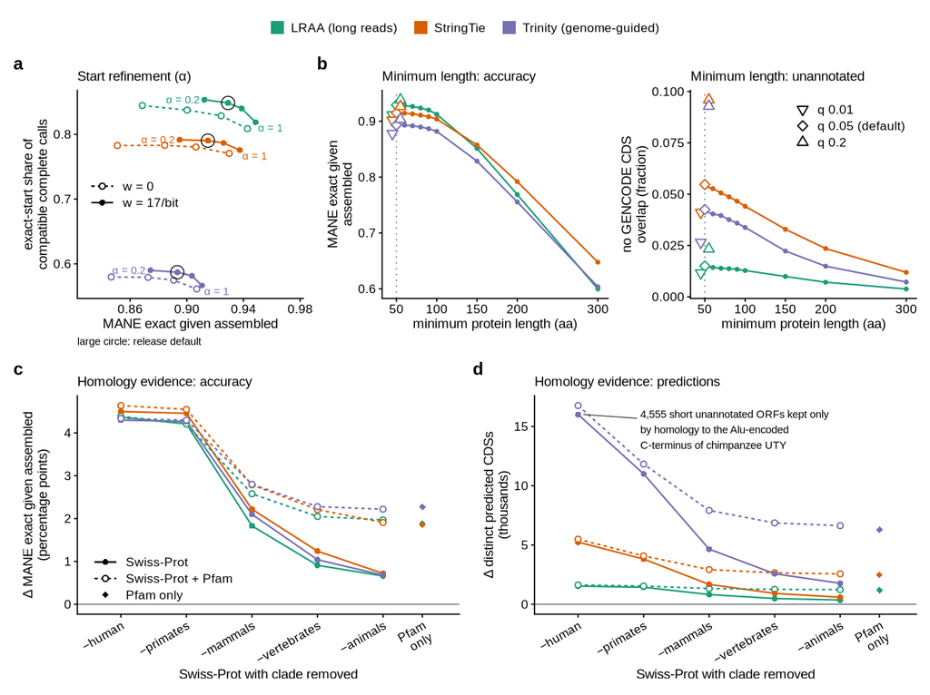

```r
fig7
```

Plotted values (each panel):

```r
kable(pa_dat %>% select(assembly, config, alpha, w, MANE_sens_exact_given_assembled,
                        pred_complete_start_precision),
      digits = 4, caption = "Panel a")
```

Panel a

| assembly | config | alpha | w | MANE_sens_exact_given_assembled | pred_complete_start_precision |
| --- | --- | --- | --- | --- | --- |
| lraa | a0.2_w0 | 0.2 | w = 0 | 0.8686 | 0.8445 |
| lraa | a0.2_w17 | 0.2 | w = 17/bit | 0.9125 | 0.8534 |
| lraa | a0.4_w0 | 0.4 | w = 0 | 0.9002 | 0.8375 |
| lraa | a0.4_w17 | 0.4 | w = 17/bit | 0.9291 | 0.8484 |
| lraa | a0.6_w0 | 0.6 | w = 0 | 0.9242 | 0.8287 |
| lraa | a0.6_w17 | 0.6 | w = 17/bit | 0.9387 | 0.8399 |
| lraa | a1_w0 | 1.0 | w = 0 | 0.9428 | 0.8087 |
| lraa | a1_w17 | 1.0 | w = 17/bit | 0.9485 | 0.8188 |
| stringtie | a0.2_w0 | 0.2 | w = 0 | 0.8510 | 0.7827 |
| stringtie | a0.2_w17 | 0.2 | w = 17/bit | 0.8948 | 0.7916 |
| stringtie | a0.4_w0 | 0.4 | w = 0 | 0.8844 | 0.7830 |
| stringtie | a0.4_w17 | 0.4 | w = 17/bit | 0.9149 | 0.7902 |
| stringtie | a0.6_w0 | 0.6 | w = 0 | 0.9064 | 0.7804 |
| stringtie | a0.6_w17 | 0.6 | w = 17/bit | 0.9259 | 0.7866 |
| stringtie | a1_w0 | 1.0 | w = 0 | 0.9299 | 0.7706 |
| stringtie | a1_w17 | 1.0 | w = 17/bit | 0.9374 | 0.7755 |
| trinity | a0.2_w0 | 0.2 | w = 0 | 0.8467 | 0.5797 |
| trinity | a0.2_w17 | 0.2 | w = 17/bit | 0.8743 | 0.5900 |
| trinity | a0.4_w0 | 0.4 | w = 0 | 0.8727 | 0.5792 |
| trinity | a0.4_w17 | 0.4 | w = 17/bit | 0.8933 | 0.5870 |
| trinity | a0.6_w0 | 0.6 | w = 0 | 0.8907 | 0.5748 |
| trinity | a0.6_w17 | 0.6 | w = 17/bit | 0.9037 | 0.5814 |
| trinity | a1_w0 | 1.0 | w = 0 | 0.9070 | 0.5612 |
| trinity | a1_w17 | 1.0 | w = 17/bit | 0.9106 | 0.5665 |

**Panel b (lines and markers)**

```r
kable(sweep_v7 %>% select(assembly, min_aa, MANE_sens_exact_given_assembled,
                          pred_all_no_GENCODE_CDS_overlap_frac), digits = 4, caption = "Panel b, lines")
```

Panel b, lines

| assembly | min_aa | MANE_sens_exact_given_assembled | pred_all_no_GENCODE_CDS_overlap_frac |
| --- | --- | --- | --- |
| lraa | 50 | 0.9287 | 0.0146 |
| lraa | 60 | 0.9279 | 0.0143 |
| lraa | 70 | 0.9266 | 0.0139 |
| lraa | 80 | 0.9236 | 0.0137 |
| lraa | 90 | 0.9201 | 0.0134 |
| lraa | 100 | 0.9125 | 0.0128 |
| lraa | 150 | 0.8513 | 0.0099 |
| lraa | 200 | 0.7688 | 0.0071 |
| lraa | 300 | 0.5996 | 0.0038 |
| stringtie | 50 | 0.9148 | 0.0538 |
| stringtie | 60 | 0.9145 | 0.0527 |
| stringtie | 70 | 0.9132 | 0.0506 |
| stringtie | 80 | 0.9109 | 0.0487 |
| stringtie | 90 | 0.9082 | 0.0466 |
| stringtie | 100 | 0.9039 | 0.0441 |
| stringtie | 150 | 0.8575 | 0.0329 |
| stringtie | 200 | 0.7919 | 0.0235 |
| stringtie | 300 | 0.6477 | 0.0119 |
| trinity | 50 | 0.8932 | 0.0416 |
| trinity | 60 | 0.8930 | 0.0404 |
| trinity | 70 | 0.8919 | 0.0396 |
| trinity | 80 | 0.8897 | 0.0376 |
| trinity | 90 | 0.8867 | 0.0359 |
| trinity | 100 | 0.8820 | 0.0338 |
| trinity | 150 | 0.8286 | 0.0223 |
| trinity | 200 | 0.7555 | 0.0149 |
| trinity | 300 | 0.6036 | 0.0072 |

```r
kable(pb_pts %>% select(assembly, qs, MANE_exact_given_assembled, no_GENCODE_overlap), digits = 4,
      caption = "Panel b, markers (at 50 aa)")
```

Panel b, markers (at 50 aa)

| assembly | qs | MANE_exact_given_assembled | no_GENCODE_overlap |
| --- | --- | --- | --- |
| lraa | q 0.05 (default) | 0.9291 | 0.0150 |
| lraa | q 0.01 | 0.9115 | 0.0116 |
| lraa | q 0.2 | 0.9385 | 0.0233 |
| stringtie | q 0.05 (default) | 0.9149 | 0.0547 |
| stringtie | q 0.01 | 0.9018 | 0.0411 |
| stringtie | q 0.2 | 0.9266 | 0.0960 |
| trinity | q 0.05 (default) | 0.8933 | 0.0425 |
| trinity | q 0.01 | 0.8779 | 0.0265 |
| trinity | q 0.2 | 0.9035 | 0.0929 |

**Panels c and d**

```r
kable(hom_pl %>% select(assembly, config, db, x, d_mane_exact_pts, d_distinct_cds), digits = 3)
```

[output not shown]

## Checks against the manuscript

Values computed here against the values in results_gm12878_parameters.tex (line numbers in the labels) and the Fig. 7 caption.

```r
check_report()
```

| claim | computed | manuscript | ok |
| --- | --- | --- | --- |
| MANE exact given assembled, no refinement (%) LRAA (long reads) | 58.58 | 58.6 | TRUE |
| MANE exact given assembled, no refinement (%) StringTie | 60.309 | 60.3 | TRUE |
| MANE exact given assembled, no refinement (%) Trinity (genome-guided) | 63.288 | 63.3 | TRUE |
| MANE exact given assembled, default (%) LRAA (long reads) | 92.914 | 92.9 | TRUE |
| MANE exact given assembled, default (%) StringTie | 91.49 | 91.5 | TRUE |
| MANE exact given assembled, default (%) Trinity (genome-guided) | 89.33 | 89.3 | TRUE |
| exact complete calls, no refinement LRAA (long reads) | 7420 | 7420 | TRUE |
| exact complete calls, no refinement StringTie | 9044 | 9044 | TRUE |
| exact complete calls, no refinement Trinity (genome-guided) | 9622 | 9622 | TRUE |
| exact complete calls, default LRAA (long reads) | 11828 | 11828 | TRUE |
| exact complete calls, default StringTie | 13395 | 13395 | TRUE |
| exact complete calls, default Trinity (genome-guided) | 13380 | 13380 | TRUE |
| 5’-partial, no refinement LRAA (long reads) | 10348 | 10348 | TRUE |
| 5’-partial, no refinement StringTie | 9483 | 9483 | TRUE |
| 5’-partial, no refinement Trinity (genome-guided) | 16006 | 16006 | TRUE |
| 5’-partial, default LRAA (long reads) | 2502 | 2502 | TRUE |
| 5’-partial, default StringTie | 2646 | 2646 | TRUE |
| 5’-partial, default Trinity (genome-guided) | 5931 | 5931 | TRUE |
| exact-start share, no refinement (%) LRAA (long reads) | 82.18 | 82.2 | TRUE |
| exact-start share, no refinement (%) StringTie | 73.925 | 73.9 | TRUE |
| exact-start share, no refinement (%) Trinity (genome-guided) | 53.066 | 53.1 | TRUE |
| exact-start share, default (%) LRAA (long reads) | 84.843 | 84.8 | TRUE |
| exact-start share, default (%) StringTie | 79.022 | 79 | TRUE |
| exact-start share, default (%) Trinity (genome-guided) | 58.702 | 58.7 | TRUE |
| wrong-start complete, no refinement LRAA (long reads) | 1609 | 1609 | TRUE |
| wrong-start complete, no refinement StringTie | 3190 | 3190 | TRUE |
| wrong-start complete, no refinement Trinity (genome-guided) | 8510 | 8510 | TRUE |
| wrong-start complete, default LRAA (long reads) | 2113 | 2113 | TRUE |
| wrong-start complete, default StringTie | 3556 | 3556 | TRUE |
| wrong-start complete, default Trinity (genome-guided) | 9413 | 9413 | TRUE |

[output cut: 121 more lines]